# Homework 5

Qingcheng Wei

October 07, 2020

# Instructions

**Exercises:** 1,3 (Pg. 227); 2 (Pg. 232); 1,2 (Pg. 235);

**Submission:** Submit via an electronic document on Sakai. Must be submitted as a HTML file generated in RStudio. All assigned problems are chosen according to the textbook *R for Data Science*. You do not need R code to answer every question. If you answer without using R code, delete the code chunk. If the question requires R code, make sure you display R code. If the question requires a figure, make sure you display a figure. A lot of the questions can be answered in written response, but require R code and/or figures for understanding and explaining.

# Chapter 12 (Pg. 227)

## Exercise 1

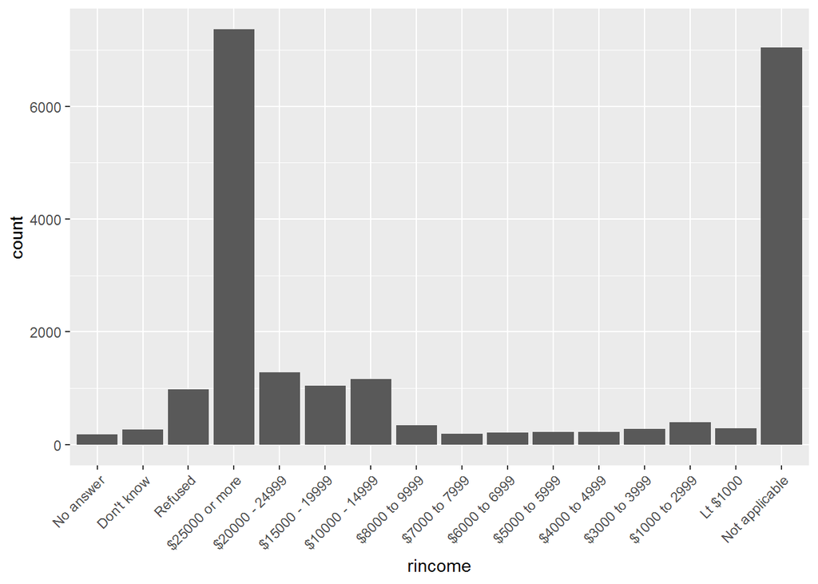

```r
ggplot(gss_cat,aes(rincome))+geom_bar()+theme(axis.text.x = element_text(angle = 45,hjust=1))+scale_x_discrete(drop=FALSE)
```

## Exercise 3

```r
gss_cat%>%count(relig,denom)
```

```
## # A tibble: 47 x 3
##    relig                   denom               n
##    <fct>                   <fct>           <int>
##  1 No answer               No answer          93
##  2 Don't know              Not applicable     15
##  3 Inter-nondenominational Not applicable    109
##  4 Native american         Not applicable     23
##  5 Christian               No answer           2
##  6 Christian               Don't know         11
##  7 Christian               No denomination   452
##  8 Christian               Not applicable    224
##  9 Orthodox-christian      Not applicable     95
## 10 Moslem/islam            Not applicable    104
## # ... with 37 more rows
```

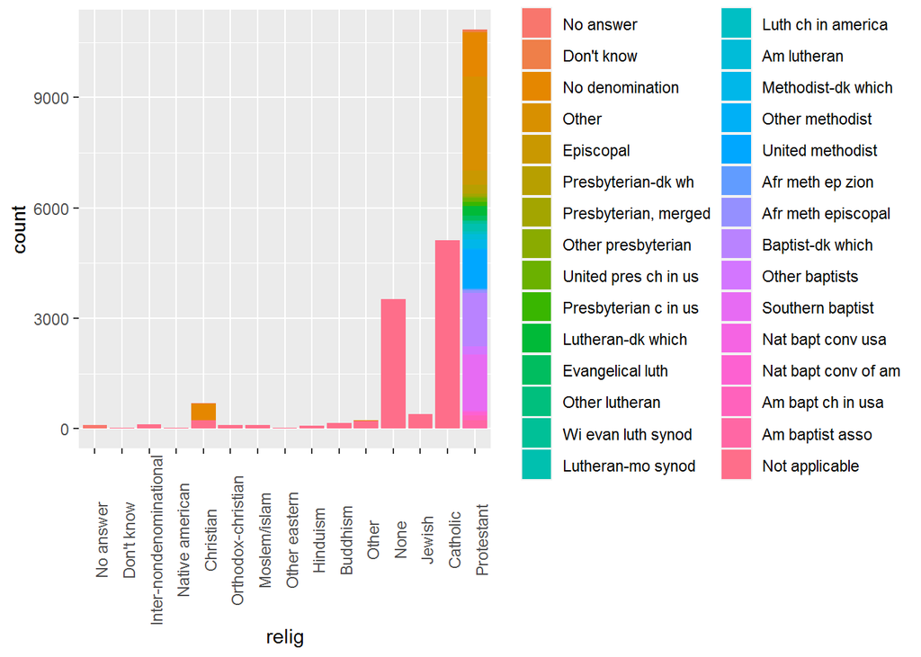

```r
ggplot(gss_cat,aes(x=relig))+geom_bar(aes(fill=denom))+theme(axis.text.x = element_text(angle = 90))
```